# Homework 2 Report

## Name

Larry Nguyen

### Setup

Read in the data with `read_csv()` and store the data as an R object named `dataset`. Check the data to make sure all of the expected observations and variables are there.

```r
## Load the data and any necessary packages here.
library(tidyverse)
dataset <- read_csv("maacs.csv.gz")
```

## Part 1

We will first consider the relationship between FEV1 and age. In general, it is expected that as children get older (and hence, larger in size), their FEV1 values should get higher.

Consider the statement “FEV1 values in children are higher in older children relative to younger children”.

Write a function in R that takes the `dataset` object as an argument and returns `TRUE` if the statement above is true for the dataset and `FALSE` otherwise.

NOTE: In order to write this function, you will need to translate the statement above into something that can be checked with the data. There are many ways in which you can do that translation correctly and you only need to pick one way here.

NOTE: For this part, do not use any plots.

```r
## Write your function here

# Returns TRUE if FEV1 and age are positively correlated, FALSE otherwise
is_fev1_age_corr = function(x) {
  correlation = cor(x$fev1, x$age, use = "complete.obs")
  if (correlation > 0) {
    return(TRUE)
  }
  return(FALSE)
}

# Execute function
is_fev1_age_corr(dataset)
```

```
## [1] TRUE
```

## Part 2

Fit a linear regression model with FEV1 as the outcome and age as a predictor.

How much does FEV1 change for a 1-year increase in the child’s age?

```r
## Add your code here

# Fitted linear regression model with FEV1 on age
model <- lm(data = dataset, fev1 ~ age)
summary(model)
```

```
##
## Call:
## lm(formula = fev1 ~ age, data = dataset)
##
## Residuals:
##      Min       1Q   Median       3Q      Max
## -1.51099 -0.27100  0.00196  0.23616  2.15477
##
## Coefficients:
##              Estimate Std. Error t value Pr(>|t|)
## (Intercept) -0.001199   0.134696  -0.009    0.993
## age          0.171162   0.010984  15.583   <2e-16 ***
## ---
## Signif. codes:  0 '***' 0.001 '**' 0.01 '*' 0.05 '.' 0.1 ' ' 1
##
## Residual standard error: 0.4827 on 131 degrees of freedom
##   (17 observations deleted due to missingness)
## Multiple R-squared:  0.6496, Adjusted R-squared:  0.6469
## F-statistic: 242.8 on 1 and 131 DF,  p-value: < 2.2e-16
```

Write your data analysis statement interpreting the regression model here:

On average, FEV1 increases by approximately 0.171 liters for each 1-year increase in the child’s age, indicating that lung function improves at children get older.

## Part 3

Develop **three** supporting premises derived from the data that support the statement you wrote in Part 2. These can be plots, other summary statistics, or model results.

NOTE: At least one supporting premise should use a plot.

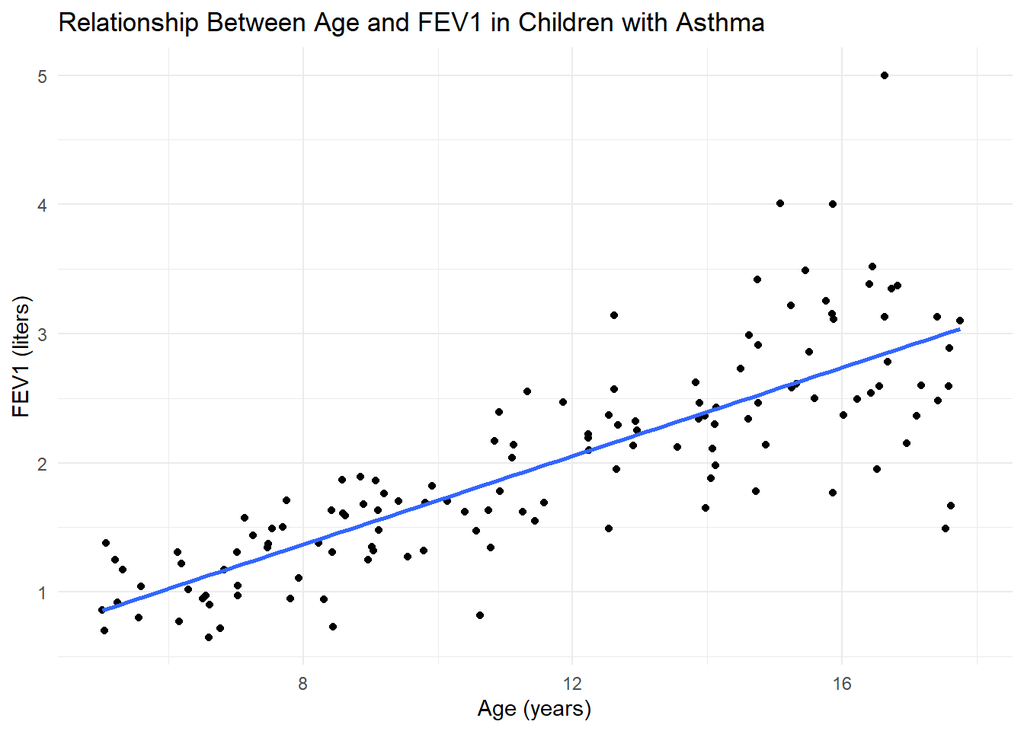

```r
## Supporting premises developed

# Scatterplot with linear regression of FEV1 on age
ggplot(dataset, aes(x = age, y = fev1)) +
  geom_point() +
  geom_smooth(method = "lm", se = FALSE) +
  labs(title = "Relationship Between Age and FEV1 in Children with Asthma", x = "Age (years)", y = "FEV1 (liters)") +
  theme_minimal()
```

```r
# Correlation between FEV1 and age separately for male and female
dataset %>%
  group_by(gender) %>%
  summarize(correlation = cor(age, fev1, use = "complete.obs"))
```

```
## # A tibble: 2 × 2
##   gender correlation
##   <chr>        <dbl>
## 1 female       0.801
## 2 male         0.827
```

```r
# Fitted linear regression model including PM2.5 as a covariate
model_pm25 <- lm(fev1 ~ age + pm25, data = dataset)
summary(model_pm25)
```

```
##
## Call:
## lm(formula = fev1 ~ age + pm25, data = dataset)
##
## Residuals:
##     Min      1Q  Median      3Q     Max
## -1.5859 -0.2834 -0.0186  0.2108  2.1143
##
## Coefficients:
##               Estimate Std. Error t value Pr(>|t|)
## (Intercept) -0.0739075  0.1493019  -0.495    0.622
## age          0.1758570  0.0122319  14.377   <2e-16 ***
## pm25         0.0008921  0.0018018   0.495    0.621
## ---
## Signif. codes:  0 '***' 0.001 '**' 0.01 '*' 0.05 '.' 0.1 ' ' 1
##
## Residual standard error: 0.4888 on 113 degrees of freedom
##   (34 observations deleted due to missingness)
## Multiple R-squared:  0.6607, Adjusted R-squared:  0.6547
## F-statistic:   110 on 2 and 113 DF,  p-value: < 2.2e-16
```

## Part 4

For each of the supporting premises above, write a function that takes the `dataset` object as an argument and returns `TRUE` if the supporting premise statement above is true for the dataset and `FALSE` otherwise.

For statements involving plots, instead of returning `TRUE` or `FALSE`, you function should do two things:

1. Produce the plot that is used in the statement
2. Produce a hypothetical version of the plot in the event that the statement is true. This can be done using simulated data or by simply hand drawing a plot.

```r
## Function for supporting premise statement 1
premise_1 <- function(x) {
  # Actual plot
  plot1 <- ggplot(x, aes(x = age, y = fev1)) +
    geom_point() +
    geom_smooth(method = "lm", se = FALSE) +
    labs(title = "Actual Relationship Between Age and FEV1", x = "Age (years)", y = "FEV1 (liters)") +
    theme_minimal()

  # Hypothetical plot
  set.seed(123)
  sim_data <- data.frame(age = seq(5, 17, length.out = 100))
  sim_data$fev1 <- 0.17 * sim_data$age + rnorm(100, mean = 0, sd = 0.5)

  plot2 <- ggplot(sim_data, aes(x = age, y = fev1)) +
    geom_point() +
    geom_smooth(method = "lm", se = FALSE) +
    labs(title = "Hypothetical Relationship Between Age and FEV1", x = "Age (years)", y = "FEV1 (liters)") +
    theme_minimal()

  # Print actual and hypothetical plots
  print(plot1)
  print(plot2)
}
```

```r
## Function for supporting premise statement 2
premise_2 <- function(x) {
  corrs <- x %>%
    group_by(gender) %>%
    summarize(correlation = cor(age, fev1, use = "complete.obs"))

  # Check if correlations for both genders are positive
  all_positive <- all(corrs$correlation > 0)
  return(all_positive)
}
```

```r
## Function for supporting premise statement 3
premise_3 <- function(x) {
  model <- lm(data = x, fev1 ~ age + pm25)
  summary_model <- summary(model)

  # Check if age coefficient is positive and significant (p < 0.05)
  age_coef <- summary_model$coefficients["age", "Estimate"]
  age_pval <- summary_model$coefficients["age", "Pr(>|t|)"]

  return(age_coef > 0 & age_pval < 0.05)
}
```

Execute each of your function and show that they produce the expected output.

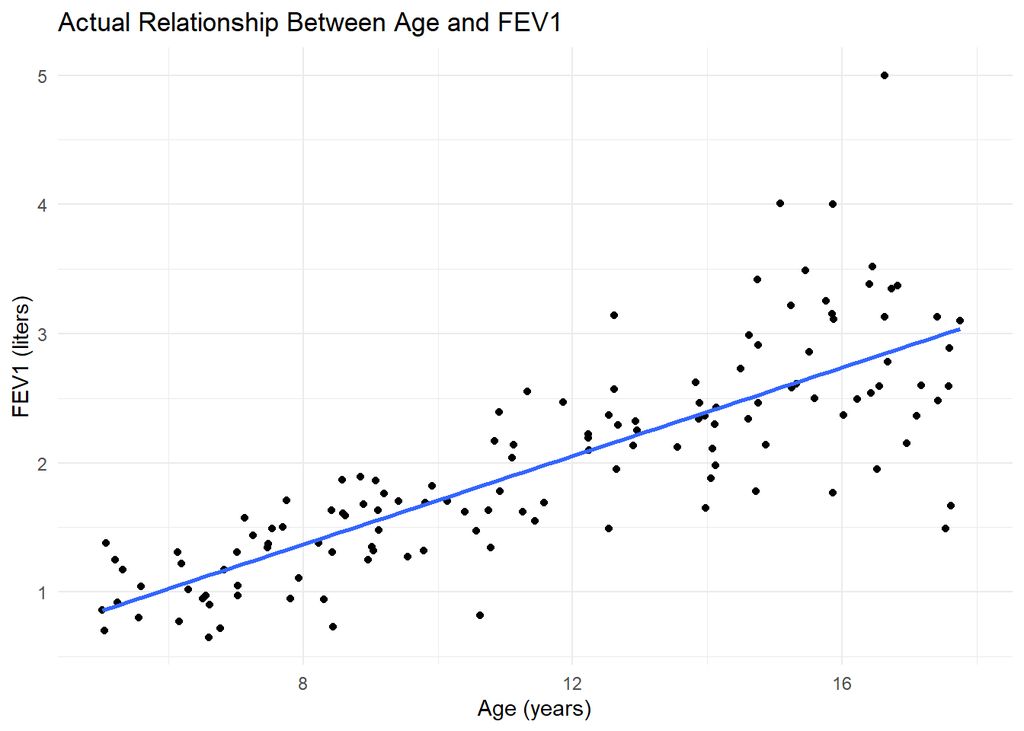

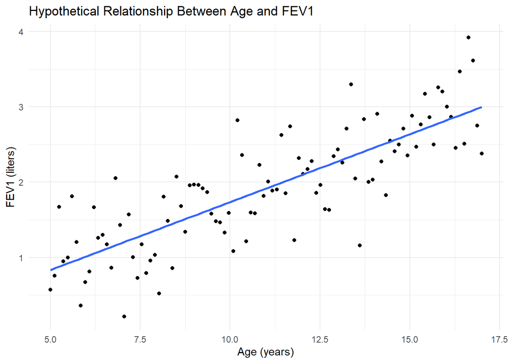

```r
premise_1(dataset)
```

```r
premise_2(dataset)
```

```
## [1] TRUE
```

```r
premise_3(dataset)
```

```
## [1] TRUE
```

## Part 5

Describe one alternative to the primary statement “FEV1 values in children are higher in older children relative to younger children”.

The observed FEV1 values may not be due to age itself, but by body size and height. Older children tend to be larger and taller than younger children, and this is a this is a confounding variable that could explain the apparent relationship between age and FEV1.

Create a fault tree for the alternative outcome describing how the alternative outcome could be realized in the data even if the primary statement were true.

Your fault tree should be created as a separate image and does not need to be created in R. Upload the image of the fault tree to Canvas.